# Predicting Breast Cancer Diagnosis Using Machine Learning

## Author

Juliet Agunobi

## Background

Breast cancer is one of the most common cancers affecting women worldwide. Early diagnosis is essential for improving treatment outcomes and survival rates. Machine learning can assist clinicians by identifying patterns in diagnostic data and supporting accurate classification of breast tumours.

## Research Question

Can machine learning models accurately classify breast tumours as benign or malignant using diagnostic measurements from the Wisconsin Breast Cancer Dataset?

## Objectives

- Load and explore the dataset
- Perform exploratory data analysis (EDA)
- Prepare the data for machine learning
- Train classification models
- Evaluate and compare model performance
- Interpret the findings

```python
# import libraries
```

```python
# Data manipulation
import pandas as pd
import numpy as np
```

```python
# Data visualization
import matplotlib.pyplot as plt
import seaborn as sns
```

```python
# Load the dataset
from sklearn.datasets import load_breast_cancer
```

```python
# Load the breast cancer dataset
breast = load_breast_cancer()

# Convert to a pandas DataFrame
df = pd.DataFrame(
    breast.data,
    columns=breast.feature_names
)

# Add the diagnosis column
df["diagnosis"] = breast.target

# Display the first five rows
df.head()
```

|  | mean radius | mean texture | mean perimeter | mean area | mean smoothness | mean compactness | mean concavity | mean concave points | mean symmetry | mean fractal dimension | ... | worst texture | worst perimeter | worst area | worst smoothness | worst compactness | worst concavity | worst concave points | worst symmetry | worst fractal dimension | diagnosis |
| --- | --- | --- | --- | --- | --- | --- | --- | --- | --- | --- | --- | --- | --- | --- | --- | --- | --- | --- | --- | --- | --- |
| 0 | 17.99 | 10.38 | 122.80 | 1001.0 | 0.11840 | 0.27760 | 0.3001 | 0.14710 | 0.2419 | 0.07871 | ... | 17.33 | 184.60 | 2019.0 | 0.1622 | 0.6656 | 0.7119 | 0.2654 | 0.4601 | 0.11890 | 0 |
| 1 | 20.57 | 17.77 | 132.90 | 1326.0 | 0.08474 | 0.07864 | 0.0869 | 0.07017 | 0.1812 | 0.05667 | ... | 23.41 | 158.80 | 1956.0 | 0.1238 | 0.1866 | 0.2416 | 0.1860 | 0.2750 | 0.08902 | 0 |
| 2 | 19.69 | 21.25 | 130.00 | 1203.0 | 0.10960 | 0.15990 | 0.1974 | 0.12790 | 0.2069 | 0.05999 | ... | 25.53 | 152.50 | 1709.0 | 0.1444 | 0.4245 | 0.4504 | 0.2430 | 0.3613 | 0.08758 | 0 |
| 3 | 11.42 | 20.38 | 77.58 | 386.1 | 0.14250 | 0.28390 | 0.2414 | 0.10520 | 0.2597 | 0.09744 | ... | 26.50 | 98.87 | 567.7 | 0.2098 | 0.8663 | 0.6869 | 0.2575 | 0.6638 | 0.17300 | 0 |
| 4 | 20.29 | 14.34 | 135.10 | 1297.0 | 0.10030 | 0.13280 | 0.1980 | 0.10430 | 0.1809 | 0.05883 | ... | 16.67 | 152.20 | 1575.0 | 0.1374 | 0.2050 | 0.4000 | 0.1625 | 0.2364 | 0.07678 | 0 |

5 rows × 31 columns

```python
df.info()
```

```
<class 'pandas.core.frame.DataFrame'>
RangeIndex: 569 entries, 0 to 568
Data columns (total 31 columns):
 #   Column                   Non-Null Count  Dtype
---  ------                   --------------  -----
 0   mean radius              569 non-null    float64
 1   mean texture             569 non-null    float64
 2   mean perimeter           569 non-null    float64
 3   mean area                569 non-null    float64
 4   mean smoothness          569 non-null    float64
 5   mean compactness         569 non-null    float64
 6   mean concavity           569 non-null    float64
 7   mean concave points      569 non-null    float64
 8   mean symmetry            569 non-null    float64
 9   mean fractal dimension   569 non-null    float64
```

[output cut: 23 more lines]

```python
df.describe()
```

|  | mean radius | mean texture | mean perimeter | mean area | mean smoothness | mean compactness | mean concavity | mean concave points | mean symmetry | mean fractal dimension | ... | worst texture | worst perimeter | worst area | worst smoothness | worst compactness | worst concavity | worst concave points | worst symmetry | worst fractal dimension | diagnosis |
| --- | --- | --- | --- | --- | --- | --- | --- | --- | --- | --- | --- | --- | --- | --- | --- | --- | --- | --- | --- | --- | --- |
| count | 569.000000 | 569.000000 | 569.000000 | 569.000000 | 569.000000 | 569.000000 | 569.000000 | 569.000000 | 569.000000 | 569.000000 | ... | 569.000000 | 569.000000 | 569.000000 | 569.000000 | 569.000000 | 569.000000 | 569.000000 | 569.000000 | 569.000000 | 569.000000 |
| mean | 14.127292 | 19.289649 | 91.969033 | 654.889104 | 0.096360 | 0.104341 | 0.088799 | 0.048919 | 0.181162 | 0.062798 | ... | 25.677223 | 107.261213 | 880.583128 | 0.132369 | 0.254265 | 0.272188 | 0.114606 | 0.290076 | 0.083946 | 0.627417 |
| std | 3.524049 | 4.301036 | 24.298981 | 351.914129 | 0.014064 | 0.052813 | 0.079720 | 0.038803 | 0.027414 | 0.007060 | ... | 6.146258 | 33.602542 | 569.356993 | 0.022832 | 0.157336 | 0.208624 | 0.065732 | 0.061867 | 0.018061 | 0.483918 |
| min | 6.981000 | 9.710000 | 43.790000 | 143.500000 | 0.052630 | 0.019380 | 0.000000 | 0.000000 | 0.106000 | 0.049960 | ... | 12.020000 | 50.410000 | 185.200000 | 0.071170 | 0.027290 | 0.000000 | 0.000000 | 0.156500 | 0.055040 | 0.000000 |
| 25% | 11.700000 | 16.170000 | 75.170000 | 420.300000 | 0.086370 | 0.064920 | 0.029560 | 0.020310 | 0.161900 | 0.057700 | ... | 21.080000 | 84.110000 | 515.300000 | 0.116600 | 0.147200 | 0.114500 | 0.064930 | 0.250400 | 0.071460 | 0.000000 |
| 50% | 13.370000 | 18.840000 | 86.240000 | 551.100000 | 0.095870 | 0.092630 | 0.061540 | 0.033500 | 0.179200 | 0.061540 | ... | 25.410000 | 97.660000 | 686.500000 | 0.131300 | 0.211900 | 0.226700 | 0.099930 | 0.282200 | 0.080040 | 1.000000 |
| 75% | 15.780000 | 21.800000 | 104.100000 | 782.700000 | 0.105300 | 0.130400 | 0.130700 | 0.074000 | 0.195700 | 0.066120 | ... | 29.720000 | 125.400000 | 1084.000000 | 0.146000 | 0.339100 | 0.382900 | 0.161400 | 0.317900 | 0.092080 | 1.000000 |
| max | 28.110000 | 39.280000 | 188.500000 | 2501.000000 | 0.163400 | 0.345400 | 0.426800 | 0.201200 | 0.304000 | 0.097440 | ... | 49.540000 | 251.200000 | 4254.000000 | 0.222600 | 1.058000 | 1.252000 | 0.291000 | 0.663800 | 0.207500 | 1.000000 |

8 rows × 31 columns

```python
df.shape
```

```
(569, 31)
```

```python
df.columns
```

```
Index(['mean radius', 'mean texture', 'mean perimeter', 'mean area',
       'mean smoothness', 'mean compactness', 'mean concavity',
       'mean concave points', 'mean symmetry', 'mean fractal dimension',
       'radius error', 'texture error', 'perimeter error', 'area error',
       'smoothness error', 'compactness error', 'concavity error',
       'concave points error', 'symmetry error', 'fractal dimension error',
       'worst radius', 'worst texture', 'worst perimeter', 'worst area',
       'worst smoothness', 'worst compactness', 'worst concavity',
       'worst concave points', 'worst symmetry', 'worst fractal dimension',
       'diagnosis'],
      dtype='object')
```

```python
df["diagnosis"].value_counts()
```

```
diagnosis
1    357
0    212
Name: count, dtype: int64
```

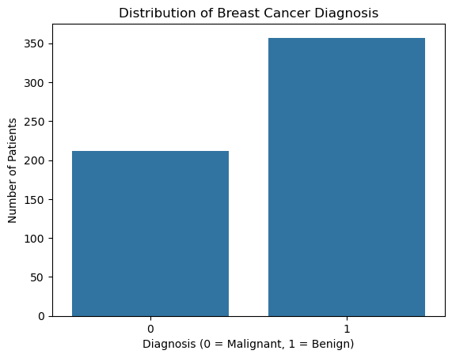

```python
# Visualize the diagnosis distribution

sns.countplot(x="diagnosis", data=df)

plt.title("Distribution of Breast Cancer Diagnosis")
plt.xlabel("Diagnosis (0 = Malignant, 1 = Benign)")
plt.ylabel("Number of Patients")

plt.show()
```

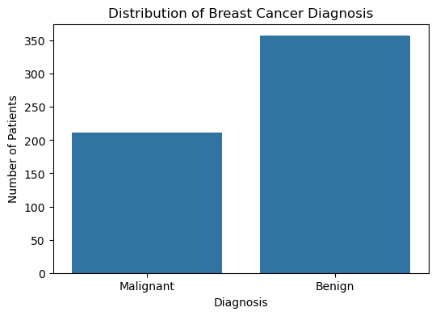

```python
plt.figure(figsize=(6,4))

ax = sns.countplot(x="diagnosis", data=df)

# Change x-axis labels
ax.set_xticklabels(["Malignant", "Benign"])

plt.title("Distribution of Breast Cancer Diagnosis")
plt.xlabel("Diagnosis")
plt.ylabel("Number of Patients")

plt.show()
```

```python
# Check for duplicate records
df.duplicated().sum()
```

```
np.int64(0)
```

## Data Quality Assessment

The dataset was examined for missing values and duplicate records before analysis.

### Findings

- No missing values were identified.
- No duplicate records were found.
- The dataset is complete and suitable for exploratory data analysis and machine learning.

```python
# Compute the correlation matrix
correlation_matrix = df.corr()

# Display the first few rows
correlation_matrix.head()
```

|  | mean radius | mean texture | mean perimeter | mean area | mean smoothness | mean compactness | mean concavity | mean concave points | mean symmetry | mean fractal dimension | ... | worst texture | worst perimeter | worst area | worst smoothness | worst compactness | worst concavity | worst concave points | worst symmetry | worst fractal dimension | diagnosis |
| --- | --- | --- | --- | --- | --- | --- | --- | --- | --- | --- | --- | --- | --- | --- | --- | --- | --- | --- | --- | --- | --- |
| mean radius | 1.000000 | 0.323782 | 0.997855 | 0.987357 | 0.170581 | 0.506124 | 0.676764 | 0.822529 | 0.147741 | -0.311631 | ... | 0.297008 | 0.965137 | 0.941082 | 0.119616 | 0.413463 | 0.526911 | 0.744214 | 0.163953 | 0.007066 | -0.730029 |
| mean texture | 0.323782 | 1.000000 | 0.329533 | 0.321086 | -0.023389 | 0.236702 | 0.302418 | 0.293464 | 0.071401 | -0.076437 | ... | 0.912045 | 0.358040 | 0.343546 | 0.077503 | 0.277830 | 0.301025 | 0.295316 | 0.105008 | 0.119205 | -0.415185 |
| mean perimeter | 0.997855 | 0.329533 | 1.000000 | 0.986507 | 0.207278 | 0.556936 | 0.716136 | 0.850977 | 0.183027 | -0.261477 | ... | 0.303038 | 0.970387 | 0.941550 | 0.150549 | 0.455774 | 0.563879 | 0.771241 | 0.189115 | 0.051019 | -0.742636 |
| mean area | 0.987357 | 0.321086 | 0.986507 | 1.000000 | 0.177028 | 0.498502 | 0.685983 | 0.823269 | 0.151293 | -0.283110 | ... | 0.287489 | 0.959120 | 0.959213 | 0.123523 | 0.390410 | 0.512606 | 0.722017 | 0.143570 | 0.003738 | -0.708984 |
| mean smoothness | 0.170581 | -0.023389 | 0.207278 | 0.177028 | 1.000000 | 0.659123 | 0.521984 | 0.553695 | 0.557775 | 0.584792 | ... | 0.036072 | 0.238853 | 0.206718 | 0.805324 | 0.472468 | 0.434926 | 0.503053 | 0.394309 | 0.499316 | -0.358560 |

5 rows × 31 columns

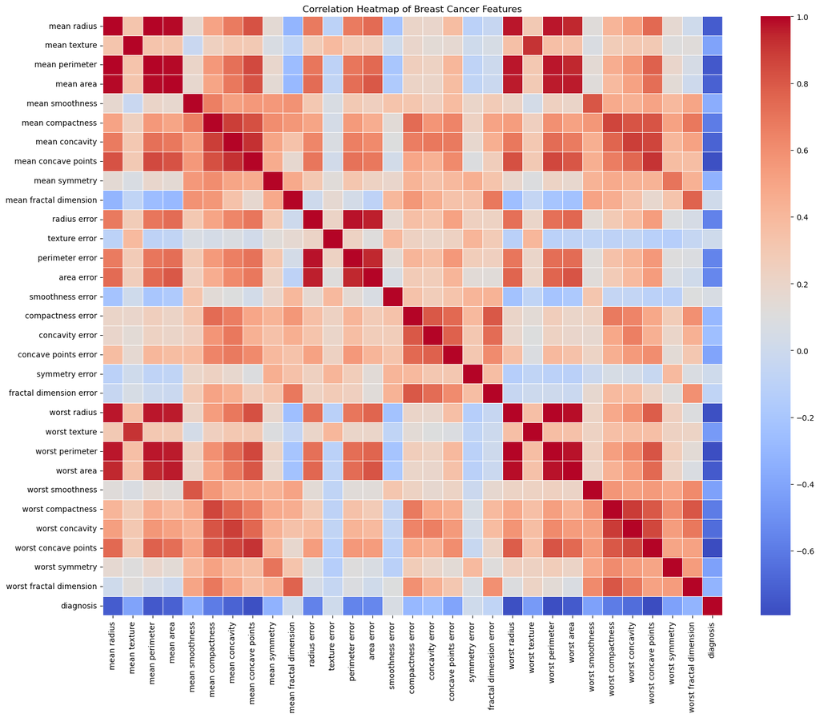

```python
plt.figure(figsize=(18, 14))

sns.heatmap(
    correlation_matrix,
    cmap="coolwarm",
    linewidths=0.5
)

plt.title("Correlation Heatmap of Breast Cancer Features")

plt.show()
```

```python
# Correlation of each feature with the diagnosis
diagnosis_corr = df.corr()["diagnosis"].sort_values()

diagnosis_corr
```

```
worst concave points      -0.793566
worst perimeter           -0.782914
mean concave points       -0.776614
worst radius              -0.776454
mean perimeter            -0.742636
worst area                -0.733825
mean radius               -0.730029
mean area                 -0.708984
mean concavity            -0.696360
worst concavity           -0.659610
mean compactness          -0.596534
worst compactness         -0.590998
radius error              -0.567134
perimeter error           -0.556141
area error                -0.548236
worst texture             -0.456903
worst smoothness          -0.421465
worst symmetry            -0.416294
mean texture              -0.415185
concave points error      -0.408042
mean smoothness           -0.358560
mean symmetry             -0.330499
worst fractal dimension   -0.323872
compactness error         -0.292999
concavity error           -0.253730
fractal dimension error   -0.077972
symmetry error             0.006522
texture error              0.008303
mean fractal dimension     0.012838
smoothness error           0.067016
diagnosis                  1.000000
Name: diagnosis, dtype: float64
```

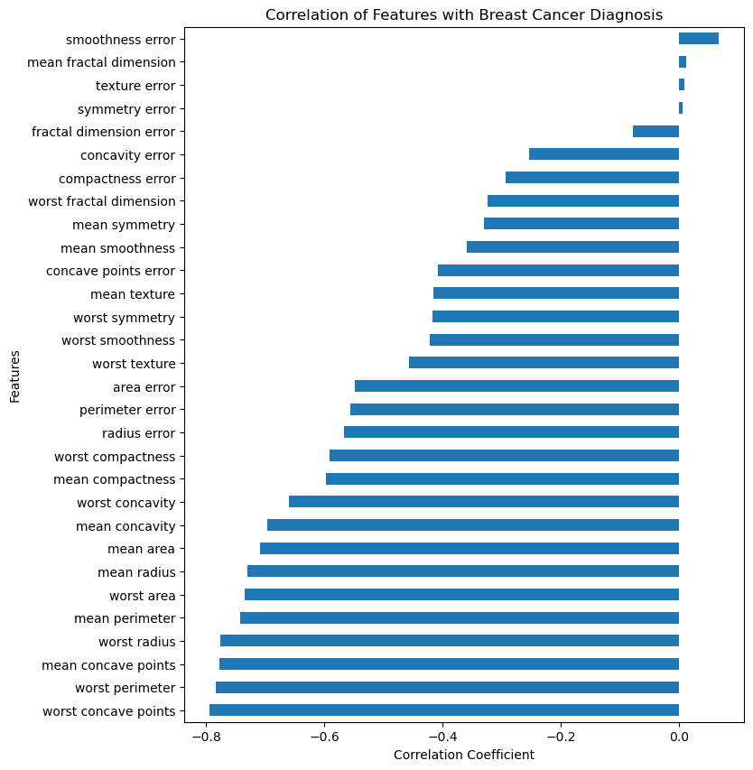

```python
plt.figure(figsize=(8,10))

diagnosis_corr[:-1].plot(kind="barh")

plt.title("Correlation of Features with Breast Cancer Diagnosis")
plt.xlabel("Correlation Coefficient")
plt.ylabel("Features")

plt.show()
```

## Feature Correlation Analysis

The correlation analysis showed that several tumour characteristics have a strong relationship with the diagnosis.

The five features with the strongest correlations were:

1. Worst concave points
2. Worst perimeter
3. Mean concave points
4. Worst radius
5. Mean perimeter

These features describe tumour size and shape. Their strong relationship with the diagnosis suggests that they are likely to be important predictors in the machine learning models developed later in this project.

```python
# Features (X) and target (y)

X = df.drop("diagnosis", axis=1)
y = df["diagnosis"]

print("Features shape:", X.shape)
print("Target shape:", y.shape)
```

```
Features shape: (569, 30)
Target shape: (569,)
```

```python
from sklearn.model_selection import train_test_split

X_train, X_test, y_train, y_test = train_test_split(
    X,
    y,
    test_size=0.2,
    random_state=42,
    stratify=y
)

print("Training set:", X_train.shape)
print("Testing set:", X_test.shape)
```

```
Training set: (455, 30)
Testing set: (114, 30)
```

```python
from sklearn.preprocessing import StandardScaler

# Create the scaler
scaler = StandardScaler()

# Fit on the training data and transform it
X_train_scaled = scaler.fit_transform(X_train)

# Transform the testing data
X_test_scaled = scaler.transform(X_test)

print("Training data shape:", X_train_scaled.shape)
print("Testing data shape:", X_test_scaled.shape)
```

```
Training data shape: (455, 30)
Testing data shape: (114, 30)
```

```python
from sklearn.linear_model import LogisticRegression

# Create the model
log_model = LogisticRegression(random_state=42)

# Train the model
log_model.fit(X_train_scaled, y_train)
```

```
LogisticRegression(random_state=42)
```

```python
# Predict on the test set
y_pred = log_model.predict(X_test_scaled)
```

```python
from sklearn.metrics import accuracy_score

accuracy = accuracy_score(y_test, y_pred)

print(f"Accuracy: {accuracy:.4f}")
```

```
Accuracy: 0.9825
```

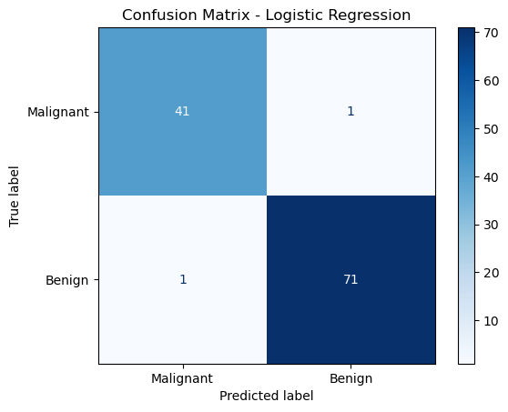

```python
from sklearn.metrics import confusion_matrix, ConfusionMatrixDisplay

# Create confusion matrix
cm = confusion_matrix(y_test, y_pred)

# Display confusion matrix
disp = ConfusionMatrixDisplay(confusion_matrix=cm,
                              display_labels=["Malignant", "Benign"])

disp.plot(cmap="Blues")

plt.title("Confusion Matrix - Logistic Regression")

plt.show()
```

```python
from sklearn.metrics import classification_report

print(classification_report(y_test, y_pred,
                            target_names=["Malignant", "Benign"]))
```

```
              precision    recall  f1-score   support

   Malignant       0.98      0.98      0.98        42
      Benign       0.99      0.99      0.99        72

    accuracy                           0.98       114
   macro avg       0.98      0.98      0.98       114
weighted avg       0.98      0.98      0.98       114
```

## Logistic Regression Performance

The Logistic Regression model achieved an overall accuracy of **98.25%** on the test dataset.

For malignant tumours, the model achieved:

- Precision: **0.98**
- Recall: **0.98**
- F1-score: **0.98**

For benign tumours, the model achieved:

- Precision: **0.99**
- Recall: **0.99**
- F1-score: **0.99**

These results indicate that the model can accurately distinguish between benign and malignant breast tumours. The high recall for malignant cases suggests that very few cancer cases were missed, which is particularly important in a clinical setting where early detection can influence patient outcomes.

Although these results are promising, the model was evaluated on a single public dataset and should not be considered suitable for clinical use without external validation and further testing on independent patient populations.

```python
from sklearn.tree import DecisionTreeClassifier
from sklearn.metrics import accuracy_score, classification_report
```

```python
# Create the Decision Tree model
dt_model = DecisionTreeClassifier(random_state=42)

# Train the model
dt_model.fit(X_train, y_train)
```

```
DecisionTreeClassifier(random_state=42)
```

```python
# Make predictions
dt_pred = dt_model.predict(X_test)
```

```python
dt_accuracy = accuracy_score(y_test, dt_pred)

print(f"Decision Tree Accuracy: {dt_accuracy:.4f}")
```

```
Decision Tree Accuracy: 0.9123
```

```python
print(classification_report(
    y_test,
    dt_pred,
    target_names=["Malignant", "Benign"]
))
```

```
              precision    recall  f1-score   support

   Malignant       0.85      0.93      0.89        42
      Benign       0.96      0.90      0.93        72

    accuracy                           0.91       114
   macro avg       0.90      0.92      0.91       114
weighted avg       0.92      0.91      0.91       114
```

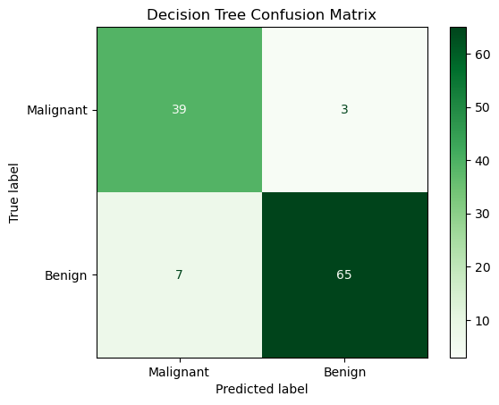

```python
from sklearn.metrics import ConfusionMatrixDisplay, confusion_matrix

cm = confusion_matrix(y_test, dt_pred)

disp = ConfusionMatrixDisplay(
    confusion_matrix=cm,
    display_labels=["Malignant", "Benign"]
)

disp.plot(cmap="Greens")

plt.title("Decision Tree Confusion Matrix")

plt.show()
```

## Decision Tree Performance

The Decision Tree classifier achieved an accuracy of **91.23%**, which is lower than the Logistic Regression model.

Although the Decision Tree identified many malignant tumours, its overall precision and F1-score were lower, indicating more misclassifications.

Compared with Logistic Regression, the Decision Tree demonstrated weaker predictive performance on this dataset.

```python
from sklearn.ensemble import RandomForestClassifier
```

```python
# Create the Random Forest model
rf_model = RandomForestClassifier(
    n_estimators=100,
    random_state=42
)

# Train the model
rf_model.fit(X_train, y_train)
```

```
RandomForestClassifier(random_state=42)
```

```python
rf_pred = rf_model.predict(X_test)
```

```python
rf_accuracy = accuracy_score(y_test, rf_pred)

print(f"Random Forest Accuracy: {rf_accuracy:.4f}")
```

```
Random Forest Accuracy: 0.9561
```

```python
print(classification_report(
    y_test,
    rf_pred,
    target_names=["Malignant", "Benign"]
))
```

```
              precision    recall  f1-score   support

   Malignant       0.95      0.93      0.94        42
      Benign       0.96      0.97      0.97        72

    accuracy                           0.96       114
   macro avg       0.96      0.95      0.95       114
weighted avg       0.96      0.96      0.96       114
```

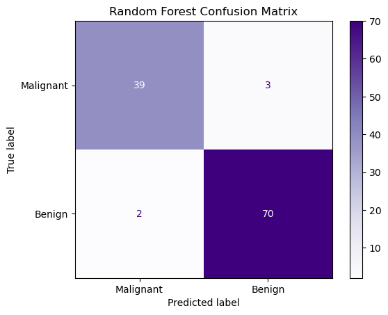

```python
cm = confusion_matrix(y_test, rf_pred)

disp = ConfusionMatrixDisplay(
    confusion_matrix=cm,
    display_labels=["Malignant", "Benign"]
)

disp.plot(cmap="Purples")

plt.title("Random Forest Confusion Matrix")

plt.show()
```

## Random Forest Performance

The Random Forest classifier achieved an overall accuracy of **95.61%**.

Compared with the Decision Tree, the Random Forest demonstrated improved predictive performance, highlighting the benefit of combining multiple decision trees to reduce overfitting.

However, Logistic Regression remained the best-performing model on this dataset, achieving the highest accuracy and stronger performance across the evaluation metrics.

```python
from sklearn.svm import SVC
```

```python
# Create the SVM model
svm_model = SVC(kernel="linear", random_state=42)

# Train the model
svm_model.fit(X_train_scaled, y_train)
```

```
SVC(kernel='linear', random_state=42)
```

```python
svm_pred = svm_model.predict(X_test_scaled)
```

```python
svm_accuracy = accuracy_score(y_test, svm_pred)

print(f"SVM Accuracy: {svm_accuracy:.4f}")
```

```
SVM Accuracy: 0.9737
```

```python
print(classification_report(
    y_test,
    svm_pred,
    target_names=["Malignant", "Benign"]
))
```

```
              precision    recall  f1-score   support

   Malignant       0.95      0.98      0.96        42
      Benign       0.99      0.97      0.98        72

    accuracy                           0.97       114
   macro avg       0.97      0.97      0.97       114
weighted avg       0.97      0.97      0.97       114
```

## Model Comparison

Four machine learning algorithms were evaluated for breast cancer classification.

| Model | Accuracy |
| --- | --- |
| Logistic Regression | 98.25% |
| Support Vector Machine | 97.37% |
| Random Forest | 95.61% |
| Decision Tree | 91.23% |

Logistic Regression achieved the highest predictive performance on the Wisconsin Breast Cancer dataset. Although Support Vector Machine and Random Forest also performed well, Logistic Regression demonstrated the best balance of accuracy, precision, recall, and F1-score.

These findings suggest that a relatively simple linear classifier can effectively distinguish between benign and malignant tumours in this dataset.

```python
# Create a DataFrame of feature importance
feature_importance = pd.DataFrame({
    "Feature": X.columns,
    "Importance": rf_model.feature_importances_
})

# Sort from highest to lowest
feature_importance = feature_importance.sort_values(
    by="Importance",
    ascending=False
)

feature_importance.head(10)
```

|  | Feature | Importance |
| --- | --- | --- |
| 23 | worst area | 0.140016 |
| 27 | worst concave points | 0.129530 |
| 20 | worst radius | 0.097696 |
| 7 | mean concave points | 0.090885 |
| 22 | worst perimeter | 0.072226 |
| 2 | mean perimeter | 0.069574 |
| 0 | mean radius | 0.068676 |
| 6 | mean concavity | 0.057638 |
| 3 | mean area | 0.049172 |
| 26 | worst concavity | 0.034340 |

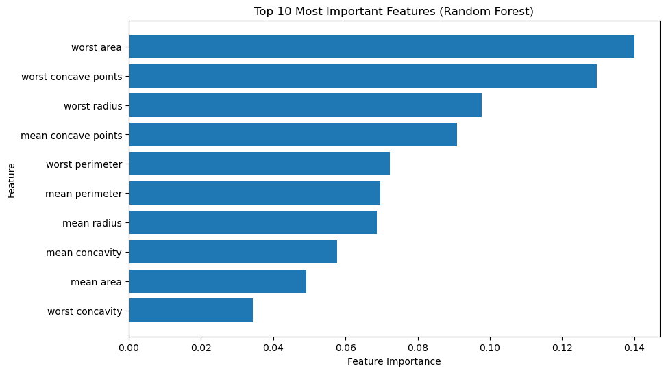

```python
plt.figure(figsize=(10,6))

top10 = feature_importance.head(10)

plt.barh(top10["Feature"], top10["Importance"])

plt.title("Top 10 Most Important Features (Random Forest)")
plt.xlabel("Feature Importance")
plt.ylabel("Feature")

plt.gca().invert_yaxis()

plt.show()
```

```python
from sklearn.metrics import roc_curve, roc_auc_score
```

```python
# Logistic Regression
lr_probs = log_model.predict_proba(X_test_scaled)[:,1]

# Random Forest
rf_probs = rf_model.predict_proba(X_test)[:,1]

# Decision Tree
dt_probs = dt_model.predict_proba(X_test)[:,1]

# SVM
svm_probs = svm_model.decision_function(X_test_scaled)
```

```python
# Logistic Regression
lr_fpr, lr_tpr, _ = roc_curve(y_test, lr_probs)

# Decision Tree
dt_fpr, dt_tpr, _ = roc_curve(y_test, dt_probs)

# Random Forest
rf_fpr, rf_tpr, _ = roc_curve(y_test, rf_probs)

# SVM
svm_fpr, svm_tpr, _ = roc_curve(y_test, svm_probs)
```

```python
lr_auc = roc_auc_score(y_test, lr_probs)
dt_auc = roc_auc_score(y_test, dt_probs)
rf_auc = roc_auc_score(y_test, rf_probs)
svm_auc = roc_auc_score(y_test, svm_probs)
```

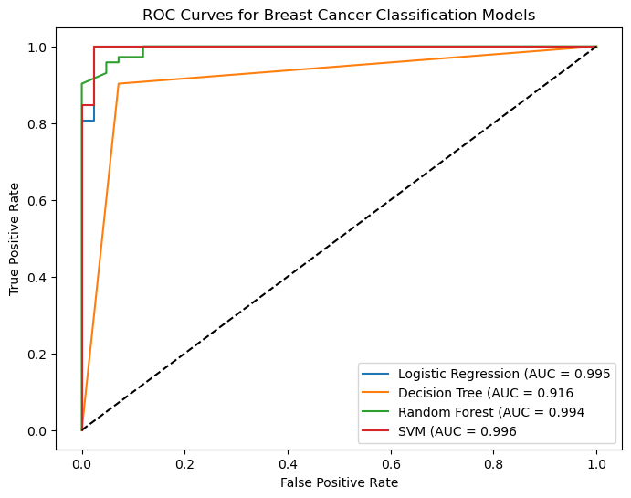

```python
plt.figure(figsize=(8,6))

plt.plot(lr_fpr, lr_tpr, label=f"Logistic Regression (AUC = {lr_auc:.3f}")
plt.plot(dt_fpr, dt_tpr, label=f"Decision Tree (AUC = {dt_auc:.3f}")
plt.plot(rf_fpr, rf_tpr, label=f"Random Forest (AUC = {rf_auc:.3f}")
plt.plot(svm_fpr, svm_tpr, label=f"SVM (AUC = {svm_auc:.3f}")

plt.plot([0,1],[0,1],'k--')

plt.xlabel("False Positive Rate")
plt.ylabel("True Positive Rate")

plt.title("ROC Curves for Breast Cancer Classification Models")

plt.legend()

plt.show()
```

```python
# Create a comparison table
comparison = pd.DataFrame({
    "Model": [
        "Logistic Regression",
        "Decision Tree",
        "Random Forest",
        "Support Vector Machine"
    ],
    "Accuracy": [
        accuracy,
        dt_accuracy,
        rf_accuracy,
        svm_accuracy
    ]
})

# Convert accuracy to percentage
comparison["Accuracy (%)"] = comparison["Accuracy"] * 100

# Sort by accuracy
comparison = comparison.sort_values(
    by="Accuracy (%)",
    ascending=False
)

comparison
```

|  | Model | Accuracy | Accuracy (%) |
| --- | --- | --- | --- |
| 0 | Logistic Regression | 0.982456 | 98.245614 |
| 3 | Support Vector Machine | 0.973684 | 97.368421 |
| 2 | Random Forest | 0.956140 | 95.614035 |
| 1 | Decision Tree | 0.912281 | 91.228070 |

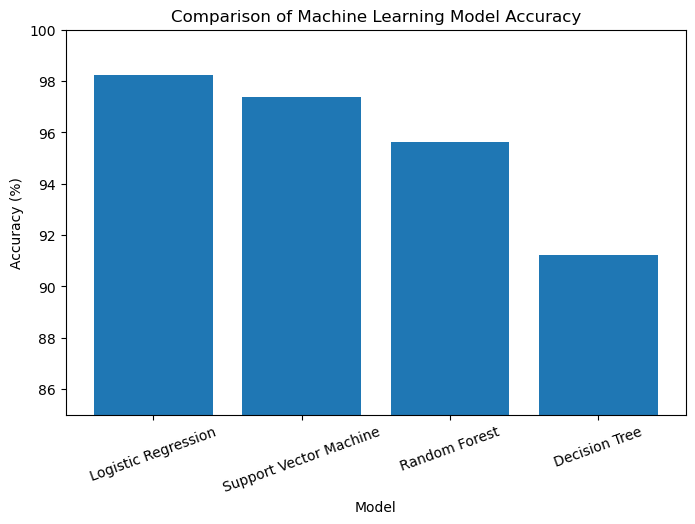

```python
plt.figure(figsize=(8,5))

plt.bar(comparison["Model"], comparison["Accuracy (%)"])

plt.title("Comparison of Machine Learning Model Accuracy")

plt.xlabel("Model")
plt.ylabel("Accuracy (%)")

plt.ylim(85,100)

plt.xticks(rotation=20)

plt.show()
```

## Comparison of Machine Learning Models

Four machine learning algorithms were evaluated for classifying breast tumours.

Among the evaluated models, **Logistic Regression** achieved the highest classification accuracy (98.25%), followed by **Support Vector Machine** (97.37%), **Random Forest** (95.61%), and **Decision Tree** (91.23%).

Although Random Forest and SVM performed well, Logistic Regression demonstrated the best overall predictive performance on this dataset. This finding suggests that the Wisconsin Breast Cancer dataset is well suited to a linear decision boundary, allowing Logistic Regression to outperform the more complex tree-based models.

# Limitations

This study has several limitations.

- The analysis used only the Wisconsin Breast Cancer Diagnostic Dataset.
- The dataset contains 569 patient records, which is relatively small for developing clinical prediction models.
- No external validation dataset was used to evaluate model generalizability.
- The models were developed for educational purposes and should not be used to support clinical decision-making without further validation.
- Feature importance indicates which variables were influential for the model on this dataset but does not establish causal relationships.

# Conclusion

This project developed and compared four machine learning models for breast cancer classification using the Wisconsin Breast Cancer Diagnostic Dataset.

Logistic Regression achieved the highest predictive performance with an accuracy of 98.25%, outperforming Decision Tree, Random Forest, and Support Vector Machine.

The analysis demonstrated that tumour characteristics related to size and shape, particularly worst area, worst concave points, and worst radius, were among the most influential features used by the Random Forest model.

Overall, this project illustrates how machine learning can assist in analysing diagnostic data while highlighting the importance of careful evaluation, model comparison, and interpretation in healthcare applications.